# Analyse des Variations de l’Emploi en Europe (1990-2023)

### M1 ISIFAR

**Université Paris Cité**

Academic Year 2024-2025

Project Members : Hengze WANG ; Ruoqi ZHU

[Github Page](https://github.com/Lambpot/Projet_ADD)

```r
to_be_loaded <- c("devtools",
                  "tidyverse",
                  "ggforce",
                  "nycflights13",
                  "patchwork",
                  "glue",
                  "DT",
                  #    "gt",
                  "kableExtra",
                  "viridis",
                  "skimr",
                  "knitr",
                  "unilur",
                  "restatapi",
                  "SparseM",
                  "ggpubr",
                  "cowplot")

for (pck in to_be_loaded) {
  if (!require(pck, character.only = TRUE)) {
    install.packages(pck)
    stopifnot(require(pck, character.only = T))
  }
}
```

# 0. Importation des données d’Eurostat

| Data code | liens et nom du data |
| --- | --- |
| lfsi_emp_a_h | [Employment and activity by sex and age (1992-2020) - annual data](https://ec.europa.eu/eurostat/databrowser/product/view/lfsi_emp_a_h?lang=en&category=labour.employ.lfsi.lfsi_emp_h) |
| lfsi_educ_a_h | [Employment by educational attainment level (1998-2020) - annual data](https://ec.europa.eu/eurostat/databrowser/product/view/lfsi_educ_a_h?lang=en&category=labour.employ.lfsi.lfsi_emp_h) |
| earn_ses18_30 | [Mean annual earnings by sex, economic activity and educational attainment](https://ec.europa.eu/eurostat/databrowser/product/view/earn_ses18_30?lang=en&category=labour.earn.earn_ses2018.earn_ses18_an… |

## Définition de la structure des données :

**DSD of Employment and activity by sex and age (1992-2020) - annual data :**

```r
datatable(get_eurostat_dsd("lfsi_emp_a_h"))
```

|  | concept | code | name |
| --- | --- | --- | --- |
| 1 | freq | A | Annual |
| 2 | age | Y15-24 | From 15 to 24 years |
| 3 | age | Y15-64 | From 15 to 64 years |
| 4 | age | Y20-64 | From 20 to 64 years |
| 5 | age | Y25-54 | From 25 to 54 years |
| 6 | age | Y55-64 | From 55 to 64 years |
| 7 | unit | THS_PER | Thousand persons |
| 8 | unit | PC_POP | Percentage of total population |
| 9 | sex | T | Total |
| 10 | sex | M | Males |

[output cut: 46 more lines]

**DSD of Employment by educational attainment level (1998-2020) - annual data :**

```r
datatable(get_eurostat_dsd("lfsi_educ_a_h"))
```

|  | concept | code | name |
| --- | --- | --- | --- |
| 1 | freq | A | Annual |
| 2 | age | Y15-24 | From 15 to 24 years |
| 3 | age | Y15-64 | From 15 to 64 years |
| 4 | age | Y20-64 | From 20 to 64 years |
| 5 | age | Y25-54 | From 25 to 54 years |
| 6 | age | Y55-64 | From 55 to 64 years |
| 7 | unit | THS_PER | Thousand persons |
| 8 | unit | PC_POP | Percentage of total population |
| 9 | unit | PC_EMP | Percentage of total employment |
| 10 | sex | T | Total |

[output cut: 46 more lines]

**DSD of Mean annual earnings by sex, economic activity and educational attainment :**

```r
datatable(get_eurostat_dsd("earn_ses18_30"))
```

|  | concept | code | name |
| --- | --- | --- | --- |
| 1 | freq | A | Annual |
| 2 | indic_se | ERN | Gross earnings |
| 3 | indic_se | BNS | Annual bonuses |
| 4 | isced11 | TOTAL | All ISCED 2011 levels |
| 5 | isced11 | ED0-2 | Less than primary, primary and lower secondary education (levels 0-2) |
| 6 | isced11 | ED3_4 | Upper secondary and post-secondary non-tertiary education (levels 3 and 4) |
| 7 | isced11 | ED5-8 | Tertiary education (levels 5-8) |
| 8 | nace_r2 | B-S | Industry, construction and services (except activities of households as employers and extra-territorial organisations and bodies) |
| 9 | nace_r2 | B-S_X_O | Industry, construction and services (except public administration, defense, compulsory social security) |
| 10 | nace_r2 | B-N | Business economy |

[output cut: 74 more lines]

# I. Exploration des données

```r
# Importer des données d'Eurostat
emp_sex_age <- get_eurostat_data("lfsi_emp_a_h")
emp_educ <- get_eurostat_data("lfsi_educ_a_h")
earn <- get_eurostat_data("earn_ses18_30")
# Visualiser la structure des données
glimpse(emp_sex_age)
```

```
Rows: 56,928
Columns: 7
$ age      <fct> Y15-24, Y15-24, Y15-24, Y15-24, Y15-24, Y15-24, Y15-24, Y15-2…
$ unit     <fct> PC_POP, PC_POP, PC_POP, PC_POP, PC_POP, PC_POP, PC_POP, PC_PO…
$ sex      <fct> F, F, F, F, F, F, F, F, F, F, F, F, F, F, F, F, F, F, F, F, F…
$ indic_em <fct> ACT, ACT, ACT, ACT, ACT, ACT, ACT, ACT, ACT, ACT, ACT, ACT, A…
$ geo      <fct> AT, AT, AT, AT, AT, AT, AT, AT, AT, AT, AT, AT, AT, AT, AT, A…
$ time     <fct> 1995, 1996, 1997, 1998, 1999, 2000, 2001, 2002, 2003, 2004, 2…
$ values   <dbl> 57.6, 55.8, 55.1, 54.7, 54.7, 50.5, 49.7, 50.3, 49.8, 53.0, 5…
```

```r
glimpse(emp_educ)
```

```
Rows: 101,703
Columns: 7
$ age     <fct> Y15-24, Y15-24, Y15-24, Y15-24, Y15-24, Y15-24, Y15-24, Y15-24…
$ unit    <fct> PC_EMP, PC_EMP, PC_EMP, PC_EMP, PC_EMP, PC_EMP, PC_EMP, PC_EMP…
$ sex     <fct> F, F, F, F, F, F, F, F, F, F, F, F, F, F, F, F, F, F, F, F, F,…
$ isced11 <fct> ED0-2, ED0-2, ED0-2, ED0-2, ED0-2, ED0-2, ED0-2, ED0-2, ED0-2,…
$ geo     <fct> AT, AT, AT, AT, AT, AT, AT, AT, AT, AT, AT, AT, AT, AT, AT, AT…
$ time    <fct> 1999, 2000, 2001, 2002, 2003, 2004, 2005, 2006, 2007, 2008, 20…
$ values  <dbl> 30.5, 29.8, 29.8, 29.9, 30.1, 22.6, 24.0, 28.0, 31.6, 31.9, 29…
```

```r
glimpse(earn)
```

```
Rows: 111,072
Columns: 9
$ indic_se <fct> BNS, BNS, BNS, BNS, BNS, BNS, BNS, BNS, BNS, BNS, BNS, BNS, B…
$ isced11  <fct> ED0-2, ED0-2, ED0-2, ED0-2, ED0-2, ED0-2, ED0-2, ED0-2, ED0-2…
$ nace_r2  <fct> B, B, B, B, B, B, B, B, B, B, B, B, B, B, B, B, B, B, B, B, B…
$ sex      <fct> F, F, F, F, F, F, F, F, F, F, F, F, F, F, F, F, F, F, F, F, F…
$ sizeclas <fct> GE10, GE10, GE10, GE10, GE10, GE10, GE10, GE10, GE10, GE10, G…
$ unit     <fct> EUR, EUR, EUR, EUR, EUR, EUR, EUR, EUR, EUR, EUR, EUR, EUR, E…
$ geo      <fct> AT, CH, CZ, DE, DK, EA17, EA18, EA19, EE, ES, EU27_2007, EU27…
$ time     <fct> 2018, 2018, 2018, 2018, 2018, 2018, 2018, 2018, 2018, 2018, 2…
$ values   <dbl> 6273, 2232, 867, 1846, 1500, 3179, 2979, 2963, 214, 2734, 300…
```

Nous avons sélectionné la dataframe “Employment and activity by sex and age (1992-2020) - annual data” à partir d’Eurostat, identifiée par le code “lfsi_emp_a_h”, que nous utilisons dans notre code. Un examen rapide avec la fonction `glimpse` révèle la présence de 7 variables, dont 6 sont qualitatives : age, unit, sex, indic_em, geo, time, et 1 variable quantitative : values.

De même, nous avons opté pour la dataframe “Employment by educational attainment level (1998-2020) - annual data” provenant d’Eurostat, identifiée par le code “lfsi_educ_a_h”, que nous utilisons également dans notre code. Un aperçu avec la fonction `glimpse` indique la présence de 7 variables, dont 6 sont qualitatives : age, unit, sex, isced11, geo, time, et 1 variable quantitative : values.

Enfin, nous avons retenu la dataframe “Mean annual earnings by sex, economic activity and educational attainment” d’Eurostat, identifiée par le code “earn_ses18_30”, que nous utilisons dans notre code. Un examen rapide avec la fonction `glimpse` montre la présence de 9 variables, dont 8 sont qualitatives : indic_se, isced11, nace_r2, sex, sizeclas, unit, geo, time, et 1 variable quantitative : values.

## 1. Filtration des données et visualiser la structure et les statistiques sommaires des données qu’on a besion et vérifier les valeurs manquantes

```r
emp_sex_age_filtered <- get_eurostat_data("lfsi_emp_a_h",
                                 filters = c("PC_POP","T","Y15-64","EMP_LFS"))
# On filtre les données qui correspondent :
# unit = PC_POP = Percentage of total population,
# sex = T = Total, age = Y15-64 = From 15 to 64 years,
# indic_em = EMP_LFS = Total employment (resident population concept -LFS);

emp_sex_age_filtered_EU27_2020 <- get_eurostat_data("lfsi_emp_a_h",
                                 filters = c("PC_POP","T","Y15-64","EU27_2020","EMP_LFS"))
# On filtre les données qui correspondent :
# unit = PC_POP = Percentage of total population,
# sex = T = Total, age = Y15-64 = From 15 to 64 years,
# geo = EU27_2020 = European Union-27 countries (from 2020),
# indic_em = EMP_LFS = Total employment (resident population concept -LFS);


# Visualiser la structure des données
glimpse(emp_sex_age_filtered)
```

```
Rows: 943
Columns: 7
$ geo      <fct> AT, AT, AT, AT, AT, AT, AT, AT, AT, AT, AT, AT, AT, AT, AT, A…
$ unit     <fct> PC_POP, PC_POP, PC_POP, PC_POP, PC_POP, PC_POP, PC_POP, PC_PO…
$ sex      <fct> T, T, T, T, T, T, T, T, T, T, T, T, T, T, T, T, T, T, T, T, T…
$ indic_em <fct> EMP_LFS, EMP_LFS, EMP_LFS, EMP_LFS, EMP_LFS, EMP_LFS, EMP_LFS…
$ age      <fct> Y15-64, Y15-64, Y15-64, Y15-64, Y15-64, Y15-64, Y15-64, Y15-6…
$ time     <fct> 1995, 1996, 1997, 1998, 1999, 2000, 2001, 2002, 2003, 2004, 2…
$ values   <dbl> 68.6, 67.9, 67.9, 68.2, 68.5, 68.5, 68.4, 68.7, 68.9, 66.5, 6…
```

```r
glimpse(emp_sex_age_filtered_EU27_2020)
```

```
Rows: 21
Columns: 7
$ geo      <fct> EU27_2020, EU27_2020, EU27_2020, EU27_2020, EU27_2020, EU27_2…
$ unit     <fct> PC_POP, PC_POP, PC_POP, PC_POP, PC_POP, PC_POP, PC_POP, PC_PO…
$ sex      <fct> T, T, T, T, T, T, T, T, T, T, T, T, T, T, T, T, T, T, T, T, T
$ indic_em <fct> EMP_LFS, EMP_LFS, EMP_LFS, EMP_LFS, EMP_LFS, EMP_LFS, EMP_LFS…
$ age      <fct> Y15-64, Y15-64, Y15-64, Y15-64, Y15-64, Y15-64, Y15-64, Y15-6…
$ time     <fct> 2000, 2001, 2002, 2003, 2004, 2005, 2006, 2007, 2008, 2009, 2…
$ values   <dbl> 61.0, 61.3, 61.2, 61.4, 61.7, 62.2, 63.2, 64.3, 64.8, 63.6, 6…
```

```r
# Statistiques de synthèse Vérification des valeurs manquantes
skimr :: skim(emp_sex_age_filtered_EU27_2020)
```

Data summary

| Name | emp_sex_age_filtered_EU27… |
| --- | --- |
| Number of rows | 21 |
| Number of columns | 7 |
| Key | NULL |
| _______________________ |  |
| Column type frequency: |  |
| factor | 6 |
| numeric | 1 |
| ________________________ |  |
| Group variables | None |

**Variable type: factor**

| skim_variable | n_missing | complete_rate | ordered | n_unique | top_counts |
| --- | --- | --- | --- | --- | --- |
| geo | 0 | 1 | FALSE | 1 | EU2: 21 |
| unit | 0 | 1 | FALSE | 1 | PC_: 21 |
| sex | 0 | 1 | FALSE | 1 | T: 21 |
| indic_em | 0 | 1 | FALSE | 1 | EMP: 21 |
| age | 0 | 1 | FALSE | 1 | Y15: 21 |
| time | 0 | 1 | FALSE | 21 | 200: 1, 200: 1, 200: 1, 200: 1 |

**Variable type: numeric**

| skim_variable | n_missing | complete_rate | mean | sd | p0 | p25 | p50 | p75 | p100 | hist |
| --- | --- | --- | --- | --- | --- | --- | --- | --- | --- | --- |
| values | 0 | 1 | 63.92 | 2.25 | 61 | 62.2 | 63.4 | 64.8 | 68.5 | ▇▇▃▂▃ |

# II. Visualisation des données (Études univariées et bivariées)

```r
# La seule variable quantitative est values(taux d'emploi), on commence avec le summary statistics :
emp_sex_age_filtered$values %>%
  skimr::skim() %>%
  select(1:11, -starts_with('skim')) %>%
  knitr::kable(caption = "Summary statistics pour taux d'emploi")
```

Summary statistics pour taux d'emploi

| n_missing | complete_rate | numeric.mean | numeric.sd | numeric.p0 | numeric.p25 | numeric.p50 | numeric.p75 | numeric.p100 |
| --- | --- | --- | --- | --- | --- | --- | --- | --- |
| 0 | 1 | 64.35408 | 7.645043 | 39.6 | 59.75 | 64.3 | 69.15 | 86.6 |

## 1. Visualisation de la distribution des taux d’emploi

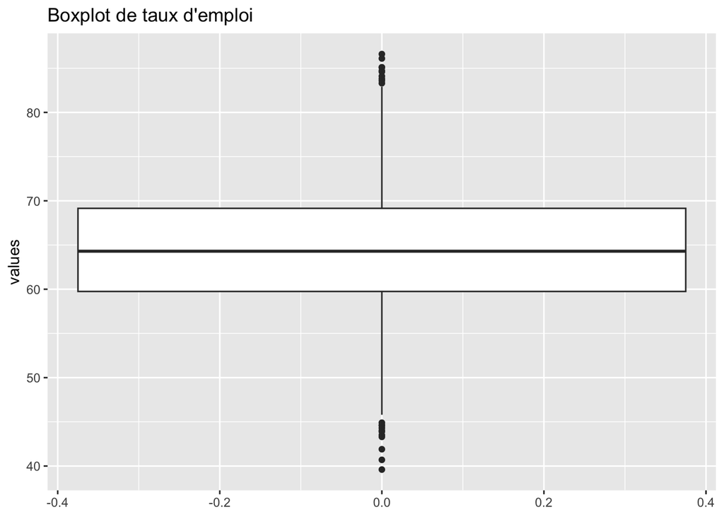

```r
# Boxplot
emp_sex_age_filtered %>%
  ggplot(aes(y = values)) +
  geom_boxplot() +
  labs(title = "Boxplot de taux d'emploi")
```

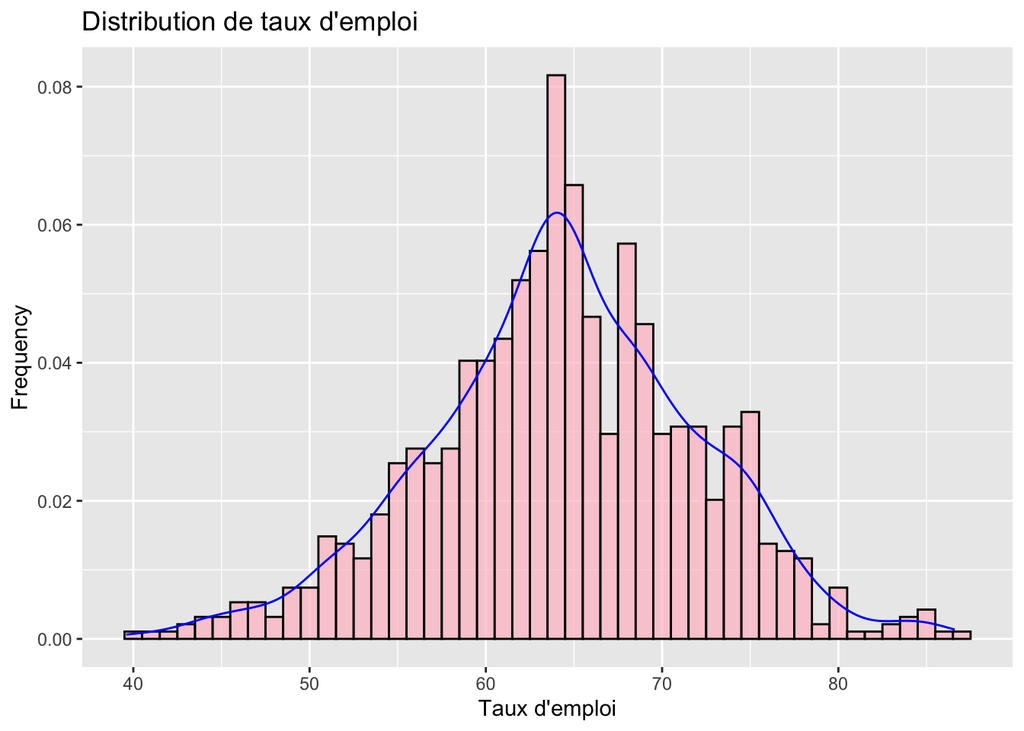

```r
# Visualisation de la distribution des taux d'emploi
ggplot(emp_sex_age_filtered, aes(x = values)) +
  geom_histogram(aes(y = after_stat(density)), binwidth = 1, fill = "pink", color = "black", alpha = 0.7) +
  labs(title = "Distribution de taux d'emploi",
       x = "Taux d'emploi",
       y = "Frequency")+
  geom_density(color = "blue")
```

En examinant la distribution du taux d’emploi global de 1992 à 2020, nous constatons que le taux d’emploi est principalement réparti entre 60% et 70%, et que le taux d’emploi se rapproche de la symétrie autour de 65 %.

Il semble que le taux d’emploi est normalement distribué, mais nous ne pouvons pas en être sûrs. Nous allons donc utiliser le graphique qq plot et calculer skewness et kurtosis pour déterminer si le taux d’emploi suit réellement une distribution normale.

```r
# QQ plot
dev.new()
qqnorm(emp_sex_age_filtered$values, main = "Q-Q Plot de taux d'emploi")
qqline(emp_sex_age_filtered$values)
```

[output not shown]

```r
# calcul de skewness et de kurtosis
library(e1071)
skewness(emp_sex_age_filtered$values)
```

```
[1] -0.1186479
```

```r
kurtosis(emp_sex_age_filtered$values)
```

```
[1] 0.1695281
```

## 2. Visualisation de l’évolution des taux d’emploi dans le temps

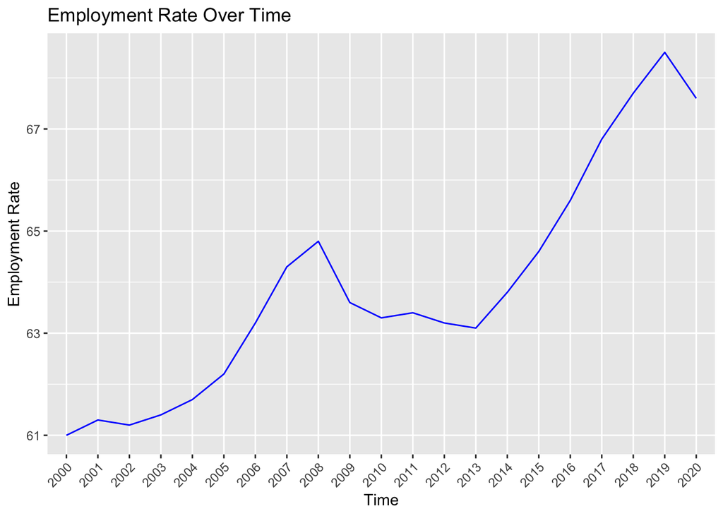

```r
ggplot(emp_sex_age_filtered_EU27_2020, aes(x = time, y = values, group = 1)) +
  geom_line(color = "blue") +
  labs(title = "Employment Rate Over Time",
       x = "Time",
       y = "Employment Rate")+
  theme(axis.text.x = element_text(angle = 45, hjust = 1))
```

## 3. Visualisation de la comparaison des taux d’emploi par sexe

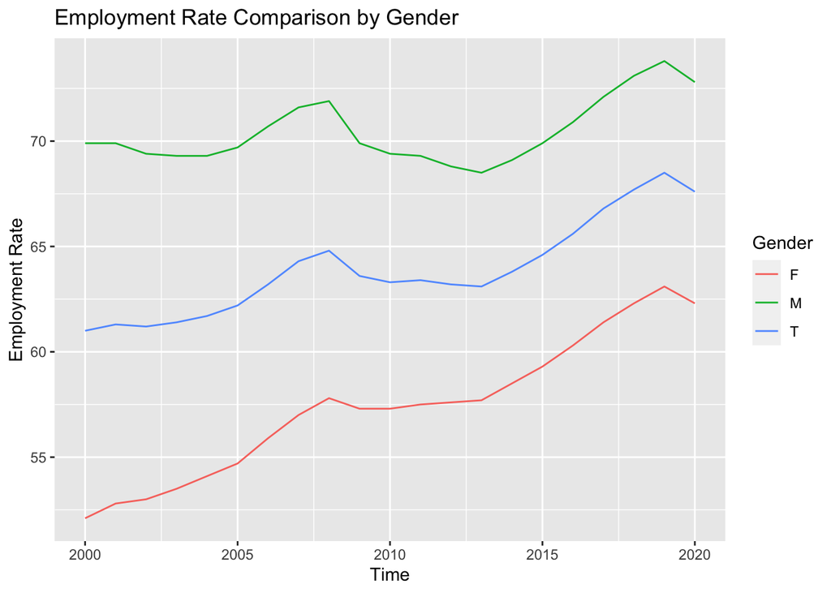

```r
# Filtration des données et comparaison des taux d'emploi par sexe
emp_data_by_sex <- get_eurostat_data("lfsi_emp_a_h",
                                     filters = c("PC_POP","Y15-64","EU27_2020","EMP_LFS"))
# Convert the time column to Date format with a fixed month and day
emp_data_by_sex$time <- as.Date(paste(emp_data_by_sex$time, "-01-01", sep = ""), format = "%Y-%m-%d")
ggplot(emp_data_by_sex, aes(x = time, y = values, color = sex)) +
  geom_line() +
  labs(title = "Employment Rate Comparison by Gender",
       x = "Time",
       y = "Employment Rate",
       color = "Gender")
```

Lors de la comparaison des taux d’emploi entre les sexes de 2000 à 2020, nous constatons que le taux d’emploi des hommes a toujours été plus élevé que celui des femmes. Le taux d’emploi des hommes fluctue autour de 70%, tandis que celui des femmes, qui était d’environ 50% en 2000, a augmenté pour atteindre un peu plus de 60%. Après 2008, le taux d’emploi des hommes a été davantage impacté par la crise économique, subissant une baisse plus significative, tandis que le taux d’emploi des femmes semble avoir été moins affecté.

## 4. Visualisation de la comparaison des taux d’emploi par groupe d’âge

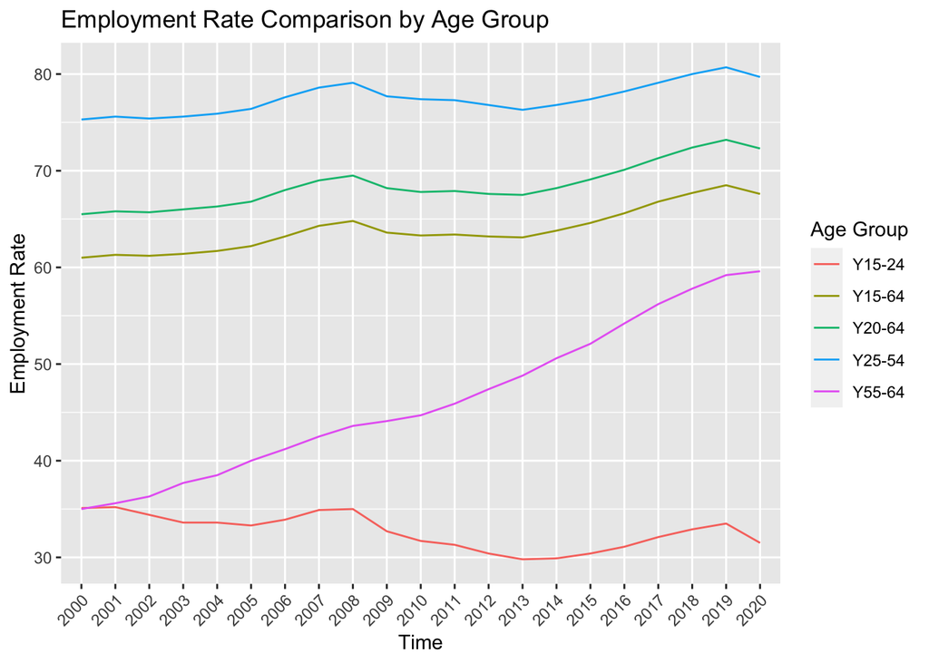

```r
emp_data_by_age <- get_eurostat_data("lfsi_emp_a_h",
                              filters = c("T","PC_POP","EU27_2020","EMP_LFS"))
emp_data_by_age <- emp_data_by_age %>% arrange(time)
ggplot(emp_data_by_age, aes(x = time, y = values, color = age, group = age)) +
  geom_line() +
  labs(title = "Employment Rate Comparison by Age Group",
       x = "Time",
       y = "Employment Rate",
       color = "Age Group")+
  theme(axis.text.x = element_text(angle = 45, hjust = 1))
```

Lors de la visualisation comparative des taux d’emploi dans différentes tranches d’âge de 15 à 24 ans, de 15 à 64 ans, de 20 à 64 ans, de 25 à 54 ans et de 55 à 64 ans de 2000 à 2020, nous avons observé deux groupes d’âge particulièrement intéressants : les jeunes de 15 à 24 ans et les personnes âgées de 55 à 64 ans.

Nous avons constaté que le taux d’emploi des jeunes de 15 à 24 ans et des personnes âgées de 55 à 64 ans était d’environ 35% en 2000. Cela signifie qu’en 2000, les taux d’emploi des jeunes et des personnes âgées étaient relativement bas, mais au fil du temps, leurs données ont divergé, suivant des trajectoires différentes. Le taux d’emploi des personnes âgées de 55 à 64 ans n’a cessé d’augmenter de 2000 à 2020, atteignant même 60% en 2020. En revanche, le taux d’emploi des jeunes de 15 à 24 ans a connu une baisse, atteignant son point le plus bas à 30%.

Nous émettons l’hypothèse que cela pourrait être dû à l’élévation constante de l’âge de la retraite, obligeant les personnes âgées à travailler pendant quelques années supplémentaires. En revanche, les jeunes pourraient nécessiter de plus en plus de temps d’éducation, passant plus de temps à étudier et à obtenir davantage de diplômes, retardant ainsi leur entrée sur le marché du travail.

## 5. Étude sur la relation entre le revenu, le sexe et l’activité

économique

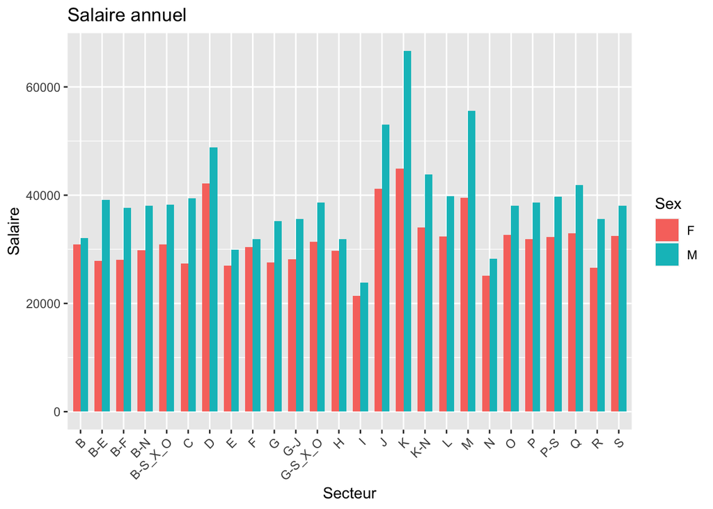

```r
salaire_dsd <- get_eurostat_dsd("earn_ses18_30")
salaire <- get_eurostat_data("earn_ses18_30",
                             filters = c("F,M","ERN", "TOTAL", "GE10", "EUR", "EU27_2020"))
salaire_sex_ecoact <- salaire %>%
filter(sex != "T")

# Visualisation
ggplot(salaire_sex_ecoact, aes(x = nace_r2, y = values, fill = sex)) +
  geom_bar(stat = "identity", position = "dodge", width = 0.7) +
  labs(title = "Salaire annuel ",
       x = "Secteur",
       y = "Salaire",
       fill = "Sex")+
  theme(axis.text.x = element_text(angle = 45, hjust = 1))
```

Dans tous les secteurs de l’UE, les salaires des hommes sont systématiquement supérieurs à ceux des femmes, avec des écarts plus importants dans les secteurs K, M, J, C, B_E (Activités financières et d’assurance; Activités scientifiques et techniques; Information et communication; Fabrication, Industrie (à l’exclusion de la construction)). En revanche, les secteurs B, E, F, H, I (Extraction de minerais et de carrières, Approvisionnement en eau; gestion des eaux usées et des déchets; Construction; Transport et entreposage; Hébergement et restauration) présentent des disparités moins marquées entre les revenus des hommes et des femmes.

Les secteurs D, J, K, M (Production et distribution d’électricité, de gaz, de vapeur et d’air conditionné; Information et communication; Activités financières et d’assurance; Activités scientifiques et techniques) affichent des niveaux de revenus élevés pour les hommes et les femmes (supérieurs à 40000); tandis que les secteurs E, I, N (Approvisionnement en eau; Gestion des eaux usées et des déchets; Hébergement et restauration; Activités de services administratifs et de soutien) présentent des niveaux de revenus plus bas (inférieurs à 30000).

# III. Régression linéaire

## Régression linéaire de salaire en fonction du taux d’emploi

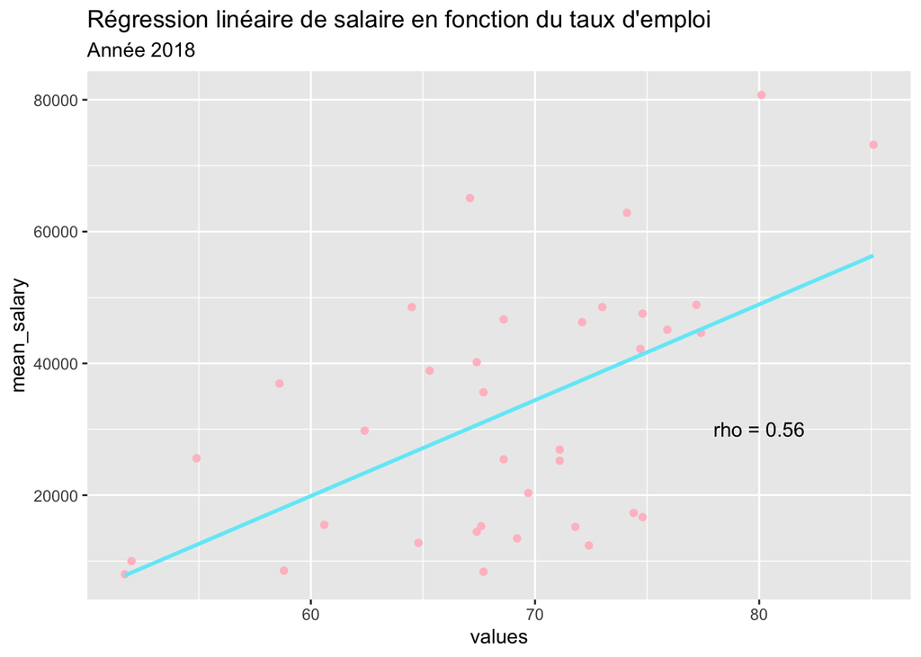

```r
salaire_dsd <- get_eurostat_dsd("earn_ses18_30")
salaire_total <- get_eurostat_data("earn_ses18_30",
                             filters = c("T","ERN", "TOTAL", "GE10", "EUR"))
salaire_sex_ecoact_total <- salaire_total %>%
  group_by(geo)%>%
  summarise(mean_salary = mean(values))

employment_geo_2018 <- get_eurostat_data("lfsi_emp_a_h",
                                 filters = c("PC_POP","T","Y15-64","EMP_LFS")) %>%
  filter( time == "2018")

emp_sal <- employment_geo_2018 %>%
  inner_join(salaire_sex_ecoact_total, by = join_by(geo))

#scatterplot
p <- emp_sal %>%
  ggplot(aes(x=values, y=mean_salary)) +
  geom_point(color='pink') +
  labs(title = "Régression linéaire de salaire en fonction du taux d'emploi",
       subtitle = "Année 2018")

rho <- cor(emp_sal$mean_salary, emp_sal$values)
#régression linéaire
p + geom_smooth(method="lm",
                se=FALSE,
                color='#71EAF8',
                formula="y~x") +
  annotate(geom = "text",
           x = 80, y = 30000,
           label = glue("rho = {round(rho, 2)}"))
```

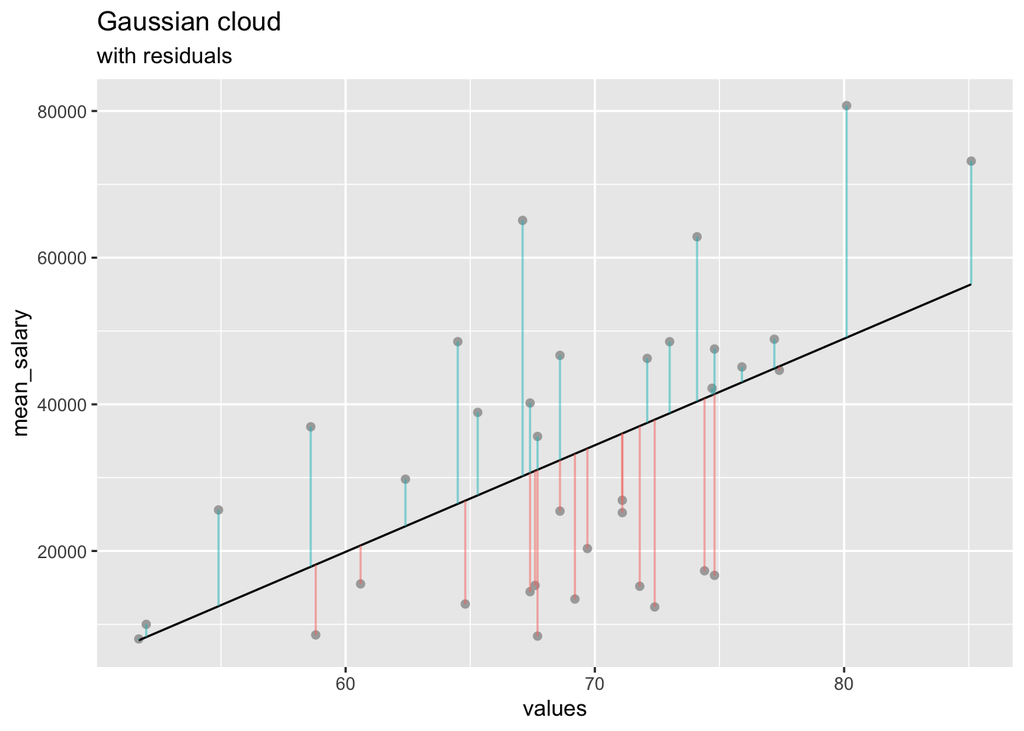

```r
# Ajustement d'un modèle linéaire
lm1 <- lm(mean_salary~values, data=emp_sal)

# Utilisation d'augment sur le modèle linéaire
emp_sal_augmented <- broom::augment(lm1)

# Création de plot
ggplot(emp_sal_augmented) +
  geom_point(aes(x = values, y = mean_salary),
             color = "darkgrey") +
  geom_line(aes(x = values, y = .fitted)) +
  geom_segment(aes(x = values, xend = values, y = .fitted, yend = mean_salary,
                   color = forcats::as_factor(sign(.resid))),
               alpha = 0.5) +
  theme(legend.position = "None") +
  ggtitle("Gaussian cloud", subtitle = "with residuals")
```

Dans le graphique de Gaussien cloud, les segments bleues représentent les résidus positifs, les segments rouges représentent les résidus négatifs, le nombre de points de résidus positifs et négatifs est approximativement égal, plus le milieu de la droite d’ajustement est proche, plus il y a de points de données, plus les résidus des données sont importants.

# IV. Évaluer la qualité des dépendances linéaires

```r
lm1 <- lm(mean_salary~values, data=emp_sal)
summary(lm1)
```

```
Call:
lm(formula = mean_salary ~ values, data = emp_sal)

Residuals:
   Min     1Q Median     3Q    Max
-25542 -13762   1343  10150  34878

Coefficients:
            Estimate Std. Error t value Pr(>|t|)
(Intercept) -67339.9    25739.9  -2.616 0.013169 *
values        1453.7      372.3   3.904 0.000425 ***
---
Signif. codes:  0 '***' 0.001 '**' 0.01 '*' 0.05 '.' 0.1 ' ' 1

Residual standard error: 16460 on 34 degrees of freedom
Multiple R-squared:  0.3096,    Adjusted R-squared:  0.2893
F-statistic: 15.25 on 1 and 34 DF,  p-value: 0.0004254
```

```r
coeff <- lm1$coefficients # â, b_chapeau
kable(coeff)
```

|  | x |
| --- | --- |
| (Intercept) | -67339.889 |
| values | 1453.744 |

```r
#Summary statistique du modèle lm1
kable(broom::tidy(lm1))
```

| term | estimate | std.error | statistic | p.value |
| --- | --- | --- | --- | --- |
| (Intercept) | -67339.889 | 25739.8632 | -2.616171 | 0.0131691 |
| values | 1453.744 | 372.3261 | 3.904493 | 0.0004254 |

```r
#Informations sur le diagnostic du modèle lm1
kable(broom::glance(lm1))
```

| r.squared | adj.r.squared | sigma | statistic | p.value | df | logLik | AIC | BIC | deviance | df.residual | nobs |
| --- | --- | --- | --- | --- | --- | --- | --- | --- | --- | --- | --- |
| 0.3095755 | 0.2892689 | 16458.6 | 15.24506 | 0.0004254 | 1 | -399.5627 | 805.1253 | 809.8759 | 9210111993 | 34 | 36 |

Selon le modèle de régression linéaire établi, nous avons étudié la relation entre le salaire moyen (‘mean_salary’) et le taux d’emploi(‘values’). Les résultats du modèle indiquent que cette relation linéaire est statistiquement significative et offre une certaine explication des variations du salaire moyen.

En conclusion, d’après les résultats de ce modèle de régression linéaire, nous pouvons affirmer que le taux d’emploi a un impact significatif sur le salaire moyen. Cependant, la capacité explicative du modèle est limitée, suggérant la nécessité d’examiner d’autres facteurs potentiels.

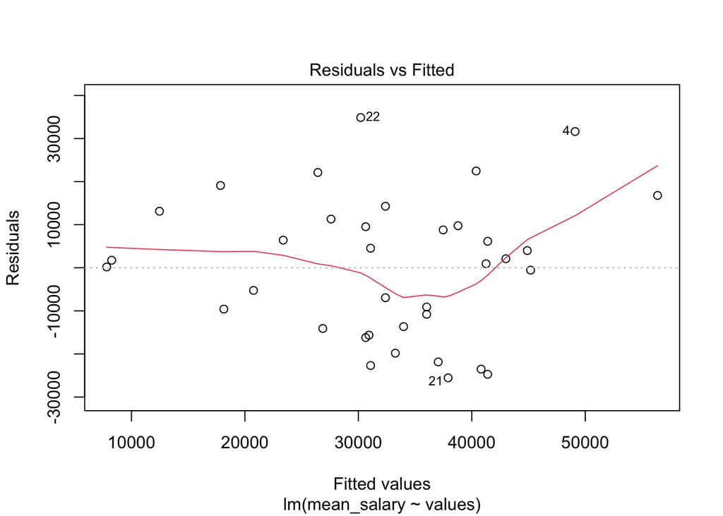

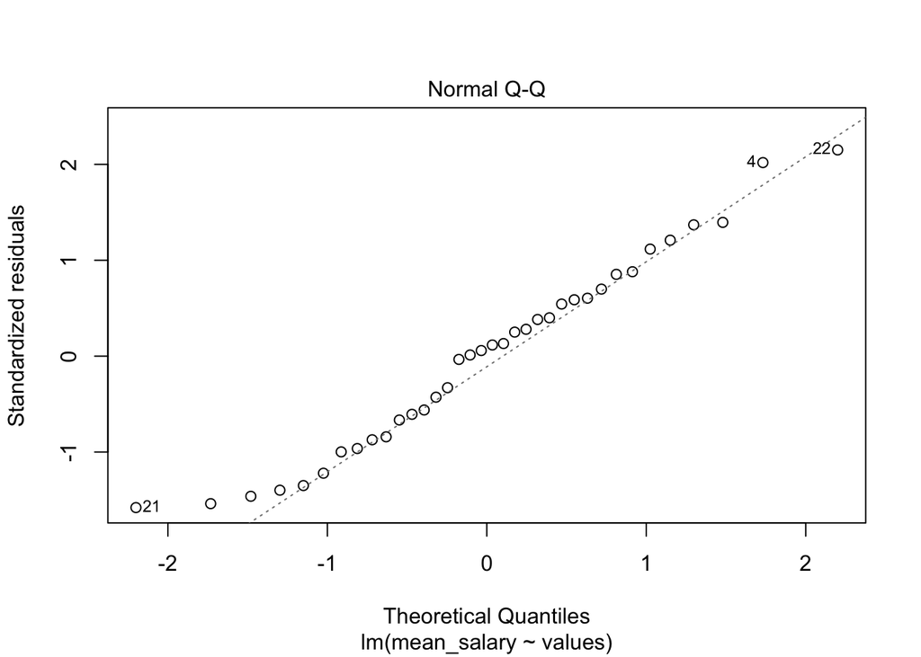

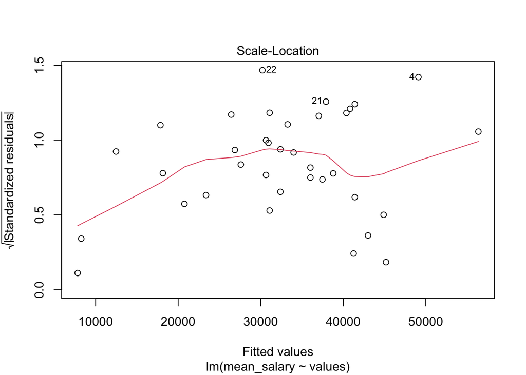

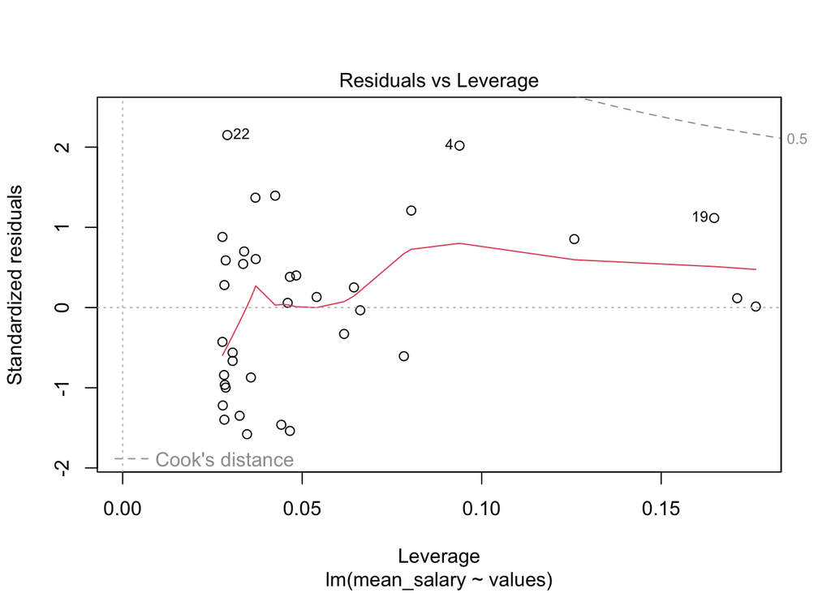

```r
#diagnostic plots
plot(lm1)
```

Le premier plot est Residuals vs Fitted Values Plot, il est pour vérifier la variance constante des résidus: la courbe rouge est la tendance des résidus (la moyenne de les residus), par observation de la courbe, on en déduit que la variance des résidus ne sont pas presque constantes, donc ŷ ne satisfait pas e~N(0, sigma²).

Le deuxième plot est Quantile-Quantile (Q-Q) Plot, il est pour vérifier la normalité des résidus: dans le graphique, nous observons que tous les points forment une ligne droite et que seul un très petit nombre de points s’écarte de la ligne, ce qui nous permet de conclure que les résidus du modèle de régression sont normalement distribués.

Le quatrième plot est Residuals vs Leverage Plot, il est pour identifier les points de données influents: dans ce plot, il n’y a pas de points se trouvent en dehors de la ligne pointillée (distance de Cook), donc il n’y a aucun point influent dans notre modèle de régression.

# V. Motivation du choix de l’ensemble de données et conclusion

Avant tout, l’étude de l’emploi revêt une importance capitale dans la compréhension des dynamiques socio-économiques. L’emploi constitue souvent la pierre angulaire de la subsistance individuelle, garantissant des revenus stables et contribuant à la stabilité financière des individus. Par ailleurs, il est étroitement lié à la croissance économique, étant un indicateur crucial d’une économie active.

Tout d’abord, l’analyse de l’emploi selon le sexe se révèle essentielle pour identifier et remédier aux disparités de genre sur le marché du travail. Cette approche contribue à promouvoir l’équité salariale, à assurer un accès équitable aux opportunités professionnelles et à lutter contre la discrimination.

Ensuite, en examinant l’emploi selon l’âge, on peut comprendre les défis spécifiques auxquels font face différentes générations. Mettre en lumière les obstacles à l’employabilité des jeunes et favoriser un environnement inclusif pour les travailleurs plus âgés devient impératif.

Par la suite, la considération de l’emploi en fonction du niveau d’éducation offre des indications sur l’équité des opportunités d’emploi en lien avec l’accès à l’éducation. Identifier les lacunes dans cet accès. Cette approche contribue à assurer que l’éducation conduit effectivement à des opportunités professionnelles équitables.

En plus, La recherche sur la relation entre le revenu, le sexe et l’activité se révèle essentielle pour comprendre les inégalités économiques et sociales. En révélant les écarts de revenu entre hommes et femmes dans tous les secteurs d’activité, cette étude offre des bases solides pour réduire l’inégalité entre les sexes dans divers domaines professionnels.

Enfin, l’étude de la dépendance linéaire entre le taux d’emploi et le salaire fournit des informations cruciales pour élaborer des politiques économiques éclairées. La conclusion d’une dépendance linéaire significative, où une augmentation du taux d’emploi est corrélée à une hausse des salaires, encourage la création d’initiatives visant à stimuler l’emploi. Cette conclusion guide également l’identification des tendances sur le marché du travail et la promotion de conditions de travail et de salaires plus équitables.

En résumé, l’étude de l’emploi sous diverses dimensions offre une perspective complète des enjeux socio-économiques. Les conclusions de ces analyses sont cruciales pour formuler des politiques inclusives, promouvoir l’équité et travailler vers des conditions de travail et des salaires plus équitables.